# Data Visualization with R: make basic exploratory plots

Yixin Wang

### 1. Data

The list of Spanish monarchs. Source: [Wikipedia](https://en.wikipedia.org/wiki/List_of_Spanish_monarchs)

| Name | Nakename | Spanish | Gender | Family | Start | End | Reignspan | Lifespan |
| --- | --- | --- | --- | --- | --- | --- | --- | --- |
| Ferdinand V & II | the Catholic | Fernando V & II | male | Trastámara | 1475 | 1504 | 29 | 63 |
| Isabella I | the Catholic | Isabel I | female | Trastámara | 1474 | 1504 | 30 | 53 |
| Joanna | the Mad | Juana I | female | Trastámara | 1504 | 1555 | 51 | 75 |
| Philip I | the Handsome | Felipe I | male | Habsburg | 1506 | 1506 | 0 | 28 |
| Charles I | the Emperor | Carlos I | male | Habsburg | 1516 | 1556 | 40 | 58 |
| Philip II | the Prudent | Felipe II | male | Habsburg | 1556 | 1598 | 42 | 71 |
| Philip III | the Pious | Felipe III | male | Habsburg | 1598 | 1621 | 23 | 42 |
| Philip IV | the Great | Felipe IV | male | Habsburg | 1621 | 1665 | 44 | 60 |
| Charles II | the Bewitched | Carlos II | male | Habsburg | 1665 | 1700 | 35 | 38 |
| Philip V | the Spirited | Felipe V | male | Bourbon | 1700 | 1746 | 46 | 62 |
| Louis I | the Beloved and the Liberal | Luis I | male | Bourbon | 1724 | 1724 | 0 | 17 |
| Ferdinand VI | the Learned | Fernando VI | male | Bourbon | 1746 | 1759 | 13 | 45 |
| Charles III | the Enlightened and the King-Mayor | Carlos III | male | Bourbon | 1759 | 1788 | 29 | 72 |
| Charles IV | the Hunter | Carlos IV | male | Bourbon | 1788 | 1808 | 20 | 70 |
| Joseph I | the Intruder and Bottle Joe | José I | male | Bonaparte | 1808 | 1813 | 5 | 76 |
| Ferdinand VII | the Desired and the Felon King | Fernando VII | male | Bourbon | 1813 | 1833 | 20 | 48 |
| Isabella II | the One with the Sad Destinies | Isabel II | female | Bourbon | 1833 | 1868 | 35 | 73 |
| Amadeo I | NA | Amadeo I | male | Savoy | 1870 | 1873 | 3 | 44 |
| Alfonso XII | the Peacemaker | Alfonso XII | male | Bourbon | 1874 | 1885 | 11 | 27 |
| Alfonso XIII | the African | Alfonso XIII | male | Bourbon | 1886 | 1931 | 45 | 54 |
| Juan Carlos I | NA | Juan Carlos I | male | Bourbon | 1975 | 2014 | 39 | NA |
| Felipe VI | NA | Felipe VI | male | Bourbon | 2014 | NA | NA | NA |

In previous posts, we talked about how to [scrape tables from Wikipedia and combine them](https://shep-herd.github.io/R-something/scrapetable.html), and [clean the raw data](https://shep-herd.github.io/R-something/cleantable.html). The clean table can be downloaded [here](https://shep-herd.github.io/rda/sp_monarchs_clean.rda). Now let’s do some exploratory visualization of the data.

### 2. Plots

```r
#Package
library(ggplot2)
```

### 2.1 Barplot

Frequency counts of houses:

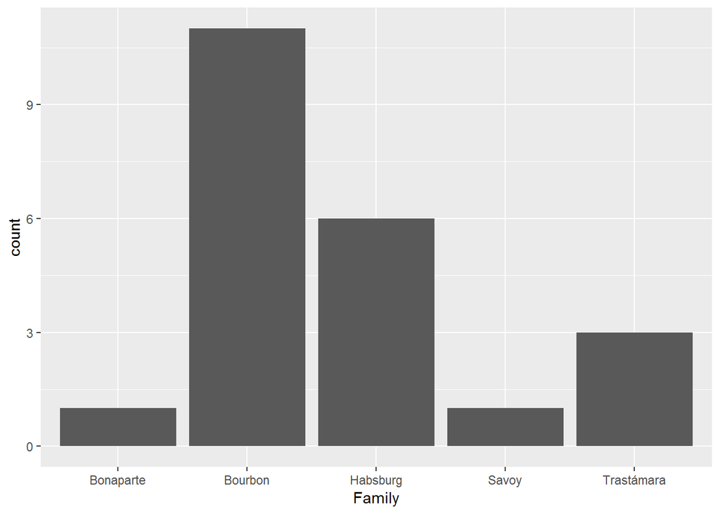

```r
#Ggplot2 makes plots by setting different layers, who are connected by + sign
#ggplot() gives the dataset [tab] and the variables to be examined
#aes() gives one categorical variable [Family] to see the frequency of its values
#geom_bar() decides the type of the plot
ggplot(tab, aes(x= Family))+ geom_bar()
```

We can see the Bourbons have the most monarchs, followed by Habsburgs and Trastámaras.

### 2.2 Histogram

Distribution of frequency of reign spans:

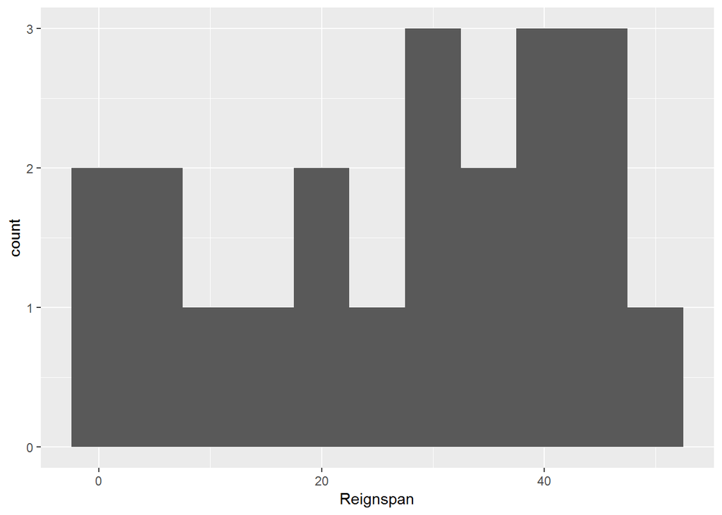

```r
#aes() gives one numerical variable [Reignspan] to see the frequency of its values
#geom_histogram() decides the type of the plot
#binwidth= 5 gives the binwidth of the histogram
ggplot(tab, aes(x= Reignspan))+ geom_histogram(binwidth = 5)
```

We can see there are two peaks. If a monarch could make it through in the first 10 years, he/she would have a big chance to reign more than 30 years! However, making it to 50 years is another thing.

### 2.3 Boxplot

Relationship between houses and reign span:

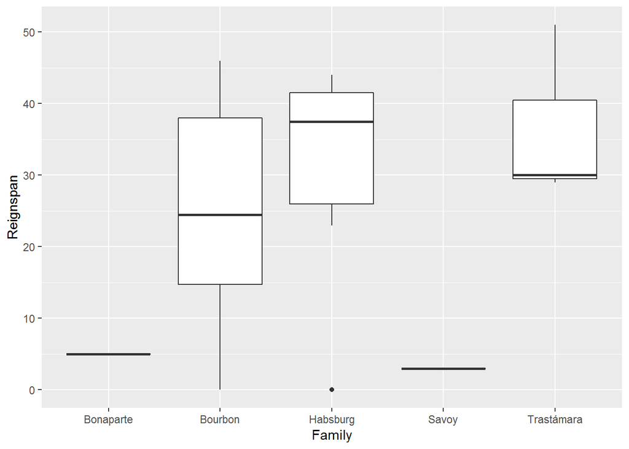

```r
#aes() gives one categorical variable [Family] to categorize another numerical variable [Reignspan]
#geom_boxplot() decides the type of the plot
ggplot(tab, aes(x= Family, y= Reignspan))+ geom_boxplot()
```

We can see the Bourbons win in number of monarchs but don’t outstand in reign span. Trastámaras have the monarch with the longest reign span but the median (the line within the box) of Habsburgs is the highest. Regarding to Bonarparte and Savoy… well…

### 2.4 Line chat

Trend of reign span:

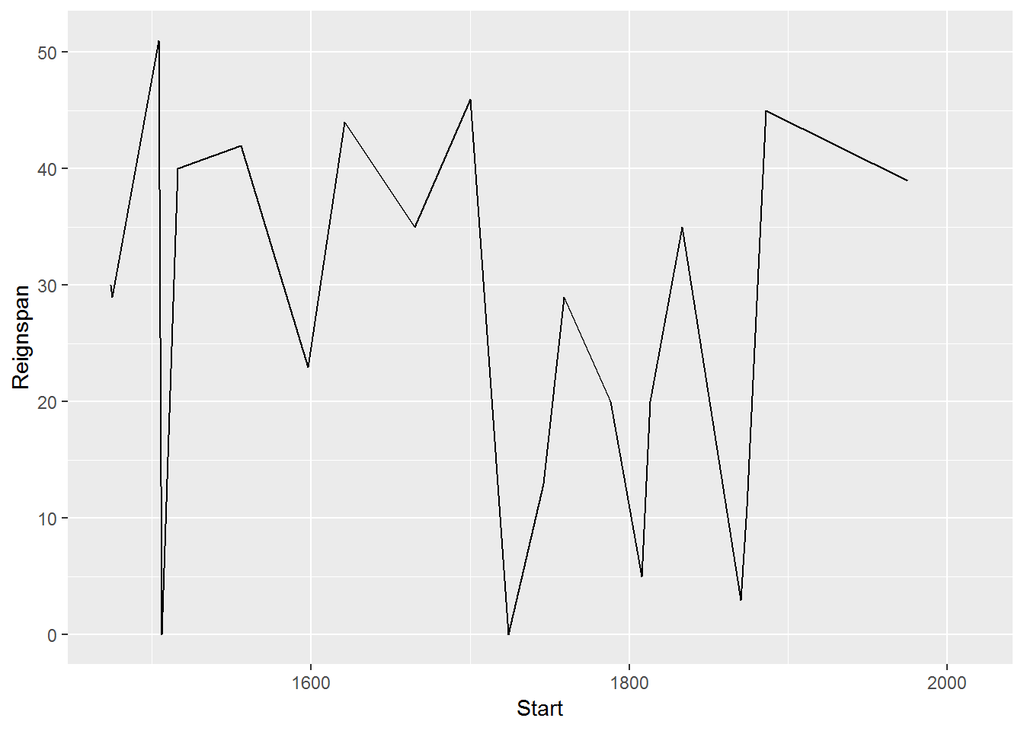

```r
#aes() gives one numerical variable [Start] to set the the time line and another numerical variable [Reignspan] to examine its trend along the time
#geom_line() decides the type of the plot
ggplot(tab, aes(x= Start, y= Reignspan))+ geom_line()
```

We can see the reign spans in the middle of the plot are shorter. The period between 1700 and 1900 must be very turbulent.

### 2.5 Scatterplot

Relationship between reign span and life span:

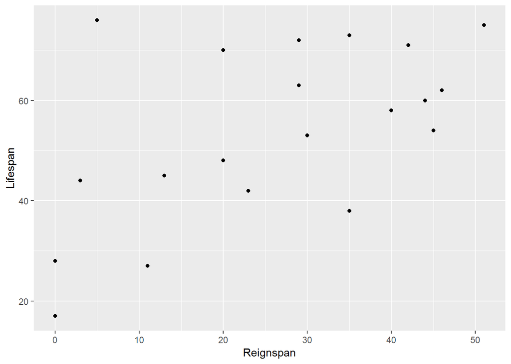

```r
#aes() gives the two numerical variable [Reignspan, Lifespan] whose correlation to be examined
#geom_point() decides the type of the plot
ggplot(tab, aes(x= Reignspan, y= Lifespan))+ geom_point()
```

Uh, the points are too scattered. Let’s add a smooth line to find some patterns:

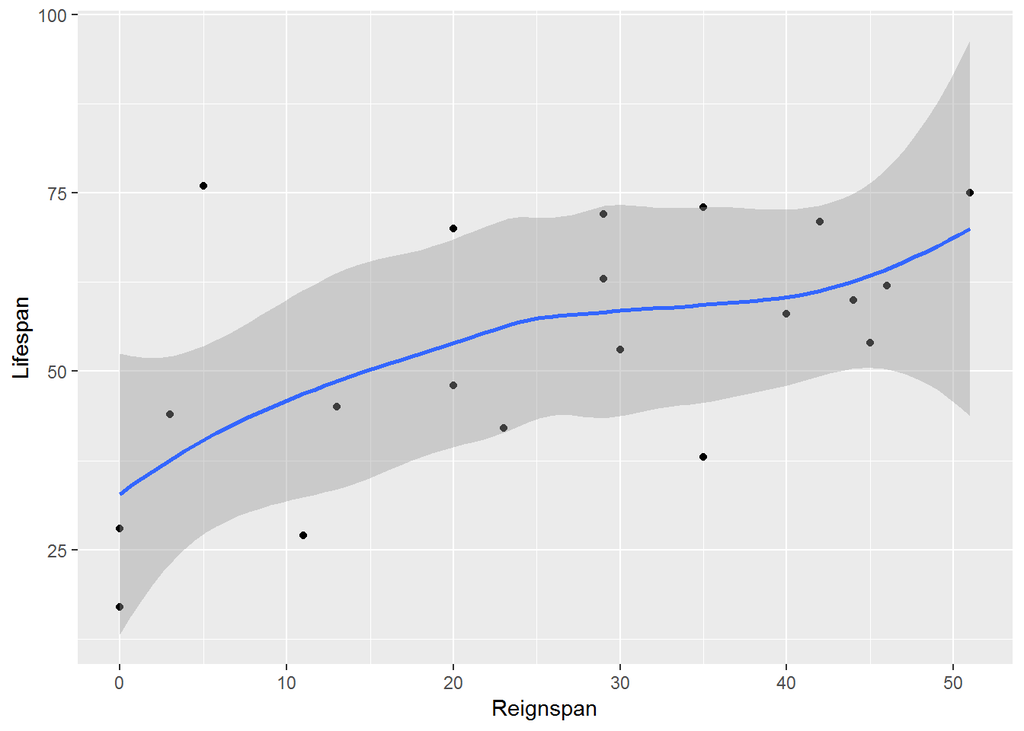

```r
#geom_smooth() adds a smooth line (mean) and area (confidence interval) to add the eye in seeing patterns
ggplot(tab, aes(x= Reignspan, y= Lifespan))+ geom_point()+ geom_smooth()
```

We can see generally those who reigned longer, also lived longer. There’s a notable outlier in the upper left corner. Let’s see who is this:

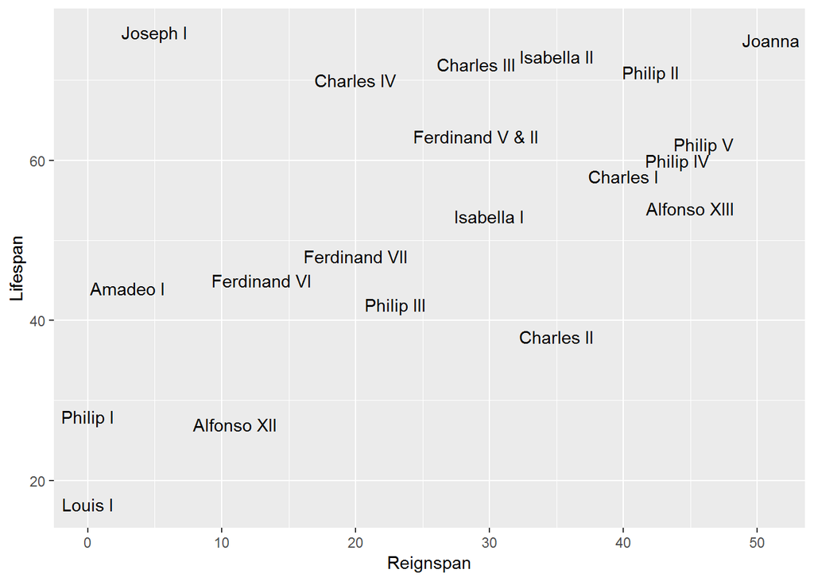

```r
#aes() gives the two numerical variable [Reignspan, Lifespan] whose correlation to be examined, and the text [Name] of each of the values
#geom_text() uses the position of the points in a scatterplot, but instead of points, shows texts
ggplot(tab, aes(x= Reignspan, y= Lifespan, label= Name))+ geom_text()
```

It turns out Joseph I is the outlier. In case that you are missing the points, the points and names can be shown at the same time:

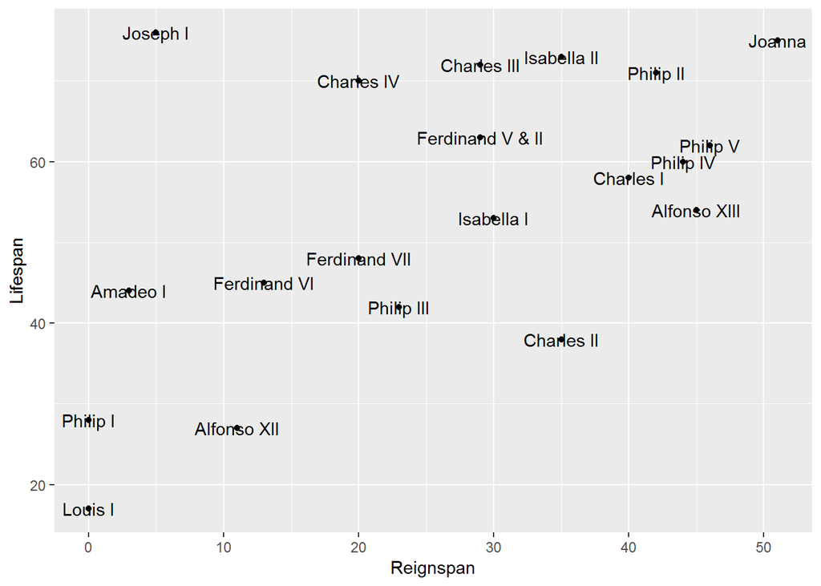

```r
#geom_text()and geom_point() are compatible layers in one plot
ggplot(tab, aes(x= Reignspan, y= Lifespan, label= Name))+ geom_text()+ geom_point()
```

This looks a bit messy. But there’s a wonderful ggplot2 extension package to “repel” the texts from the points. We will talk about it in a latter post. Now let’s see another way to show the text:

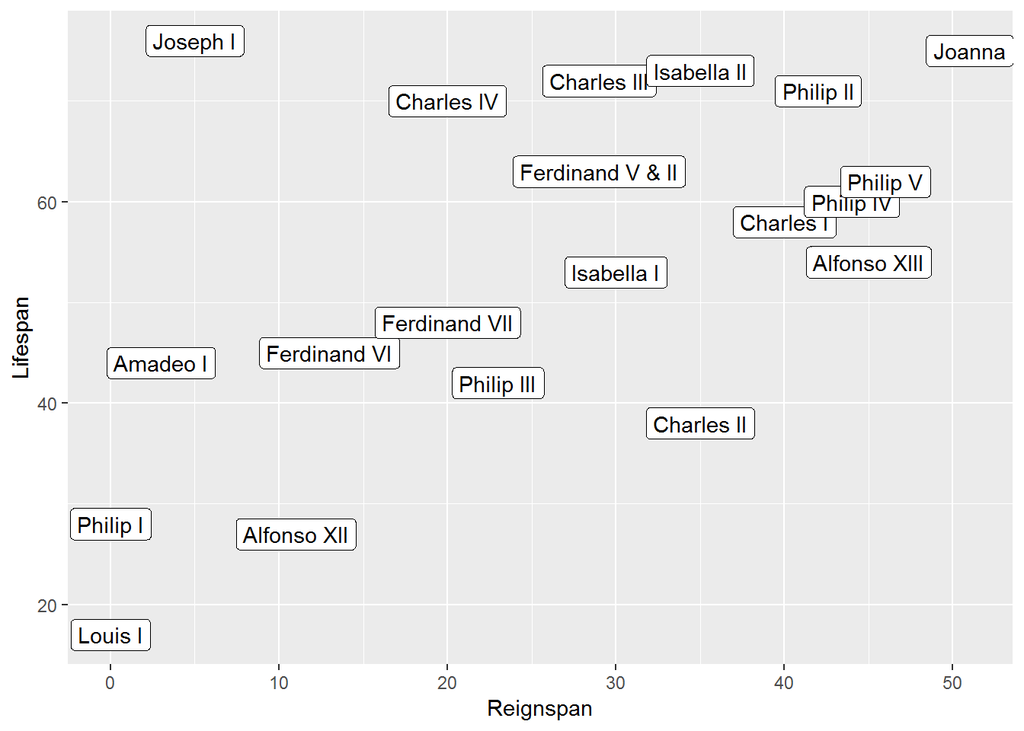

```r
#geom_label()uses the position of the points in a scatterplot, but instead of points, shows texts in labels
ggplot(tab, aes(x= Reignspan, y= Lifespan, label= Name))+ geom_label()
```

The labels make the plot look cleaner and we can add more information to the it. Let’s see the gender:

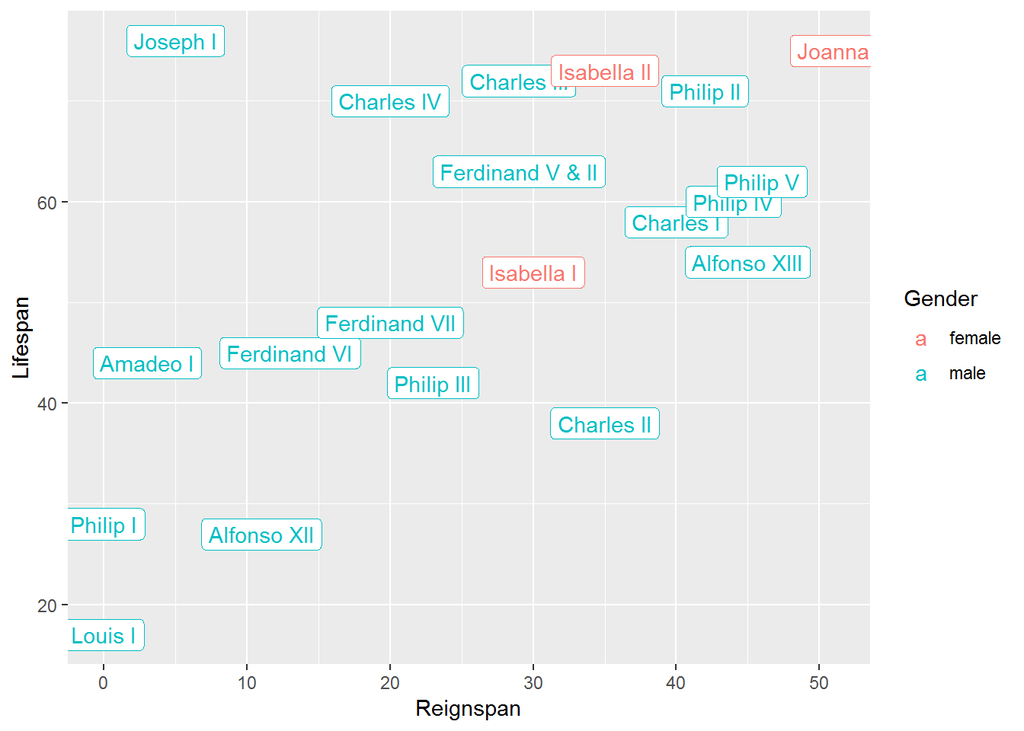

```r
#color= Gender decides the color of the line of the label by one categorical variable [Gender]
ggplot(tab, aes(x= Reignspan, y= Lifespan, label= Name, color= Gender))+ geom_label()
```

We can see there are very few females monarchs but they have done well both in reign span and life span. Let’s see the houses too:

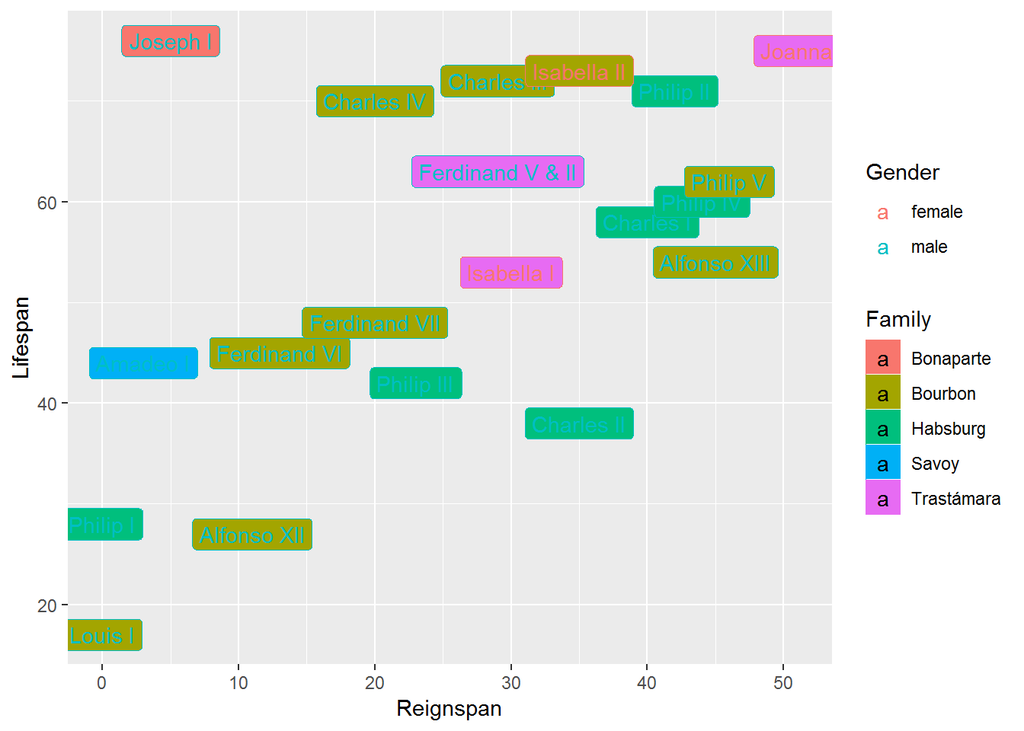

```r
#fill= Family decides the color of the fill of the label by one categorical variable [Family]
ggplot(tab, aes(x= Reignspan, y= Lifespan, label= Name, color= Gender, fill= Family))+ geom_label()
```

This plot shows at one time a great deal of information: the monarchs’ gender, house, life span, reign span and the relationship between these variable. But we need to look very carefully to find a pattern. Another way to show more information at once is using facets:

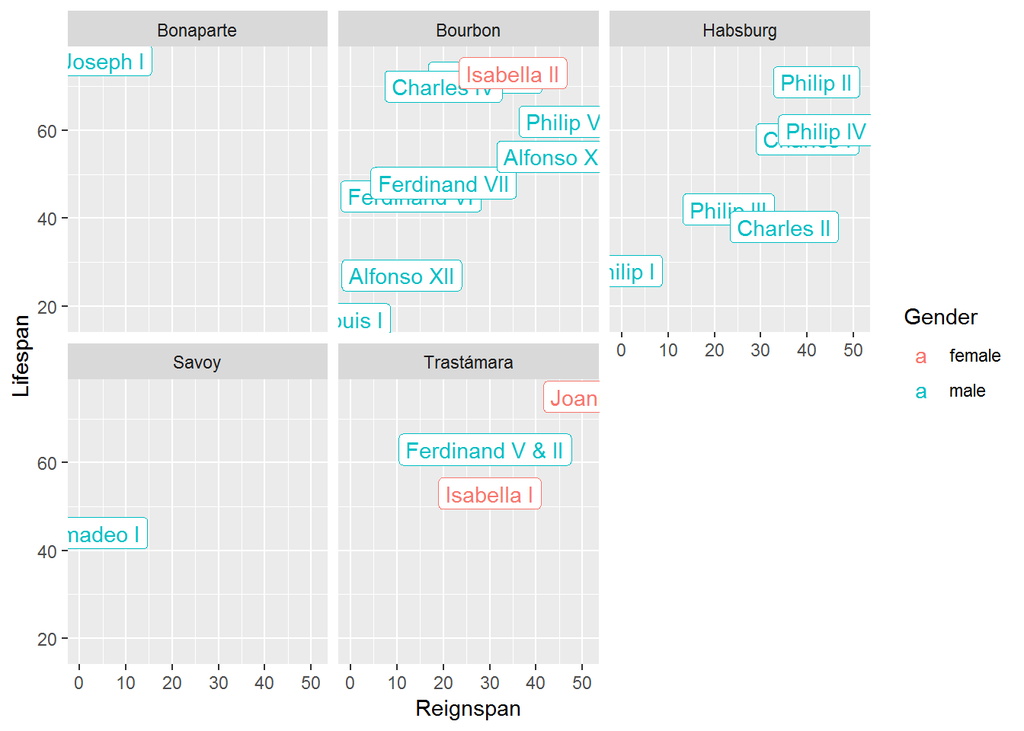

```r
#facet_wrap() gives one categorical variable [Family] to divide the data into different factes
ggplot(tab, aes(x= Reignspan, y= Lifespan, label= Name, color= Gender))+ geom_label()+ facet_wrap(~Family)
```

Facets don’t really make sense here because labels are lumped together. `facet_grid` is a similar function to `facet_wrap`. Both can be used in other types of plots as well. You can try to make your own plots about the data by combining different functions. In latter posts, we will see examples of making plots with more aesthetic concerns.

*END*

*Back to top*

[*Return to homepage*](https://shep-herd.github.io/)

First uploaded: 01-06-2019 Last updated: 02-06-2019